# Bayesian Modelling on Codon Usage Among Different Virus Genus of Coronavirus

Haogao Gu

14/08/2019

## Understand the problem

Codon usage is a famous genomic signature for many RNA viruses, including Coronavirus. In this project, we planned to investigate the distributions of the Relative Synonymous Codon Usage (rscu) of a specific codon in coronavirus of differnt virus genes, by bayesian hierarchical modelling.

## Collection of relevant data

The CDS fasta sequences were retrieved from public database. Necessary data cleaning were performed (details not shown).

## Explore the data

After some initial data cleaning, we get the data suitable for fitting a model. First we would take a overview of the data.

#### Distributions of the codon usage by different virus genus

We use the Relative Synonymous Codon Usage (RSCU) as a method to estimate the codon usage bias.

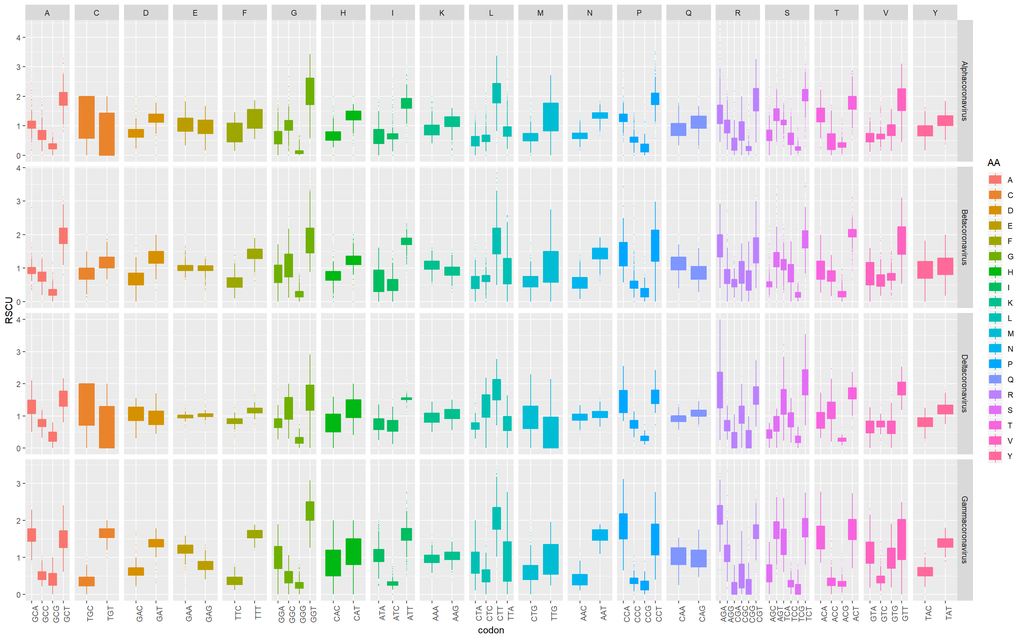

```r
ggplot(df_tmp) +
    geom_boxplot(aes(x = codon, y = RSCU, fill = AA, color = AA),
                 outlier.size = 0.1, outlier.alpha = 0.2)+
    facet_grid(vars(`Virus Genus`),vars(AA),scales = "free")+
    theme(axis.text.x = element_text(angle = 90))
```

We observed that the distributions of RSCU may vary among different groups for the TTT codon. like what is shown in the density plot below:

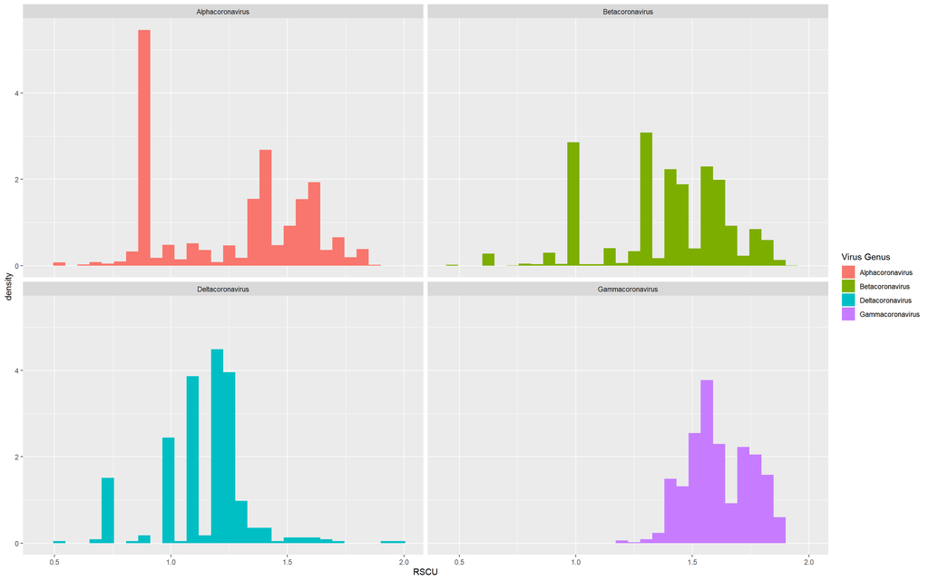

```r
ggplot(subset(df_tmp, codon == "TTT")) +
    geom_histogram(aes(x = RSCU, y = ..density.., fill = `Virus Genus`))+
    facet_wrap(vars(`Virus Genus`))
```

## Postulate a model

We assumed that And the RSCU values for each group come from individual gamma distribution with its own alpha and beta coefficients. And the alpha and beta of the distributions for different groups (virus genuses) come from two different normal distributions with different mean and variance. Thus we can build a hierarchical model basing on these data.

## Fit the model

```r
library(rjags)
df_jags <- subset(df_tmp, codon == "TTT")
df_jags$group_values <- as.numeric(factor(df_jags$`Virus Genus`))

mod_string = " model {
for (i in 1:length(RSCU)) {
  RSCU[i] ~ dgamma(alpha[group_values[i]], beta[group_values[i]])
}

for (j in 1:max(group_values)) {
  alpha[j] ~ dnorm(theta1, 1/sigma1)
  beta[j] ~ dnorm(theta2, 1/sigma2)
}

theta1 ~ dnorm(1.0, 1/100)
theta2 ~ dnorm(1.0, 1/100)

sigma1 ~ dexp(1.0)
sigma2 ~ dexp(1.0)

} "

set.seed(2019)

data_jags = as.list(df_jags)

params = c("alpha", "beta", "theta1", "theta2", "sigma1", "sigma2")

mod = jags.model(textConnection(mod_string), data=data_jags, n.chains=3)
update(mod, 1e3)

mod_sim = coda.samples(model=mod,
                       variable.names=params,
                       n.iter=5e5)
mod_csim = as.mcmc(do.call(rbind, mod_sim))

## convergence diagnostics
plot(mod_sim)

gelman.diag(mod_sim)
autocorr.diag(mod_sim)
autocorr.plot(mod_sim)
effectiveSize(mod_sim)
```

## Check the model

```r
## check the effective sample size
effectiveSize(mod_sim)
```

```
##   alpha[1]   alpha[2]   alpha[3]   alpha[4]    beta[1]    beta[2]
##  14741.680   9749.340   7904.957   2433.054  14704.347   9733.546
##    beta[3]    beta[4]     sigma1     sigma2     theta1     theta2
##   7912.173   2438.080  24355.290  46776.025 107241.731 110500.092
```

```r
## observation level residuals
(pm_params = colMeans(mod_csim))
```

```
##  alpha[1]  alpha[2]  alpha[3]  alpha[4]   beta[1]   beta[2]   beta[3]
##  16.16731  24.71182  36.55254 100.70310  12.73272  17.83231  31.88433
##   beta[4]    sigma1    sigma2    theta1    theta2
##  62.28277  47.44892  27.41422  39.91920  29.24636
```

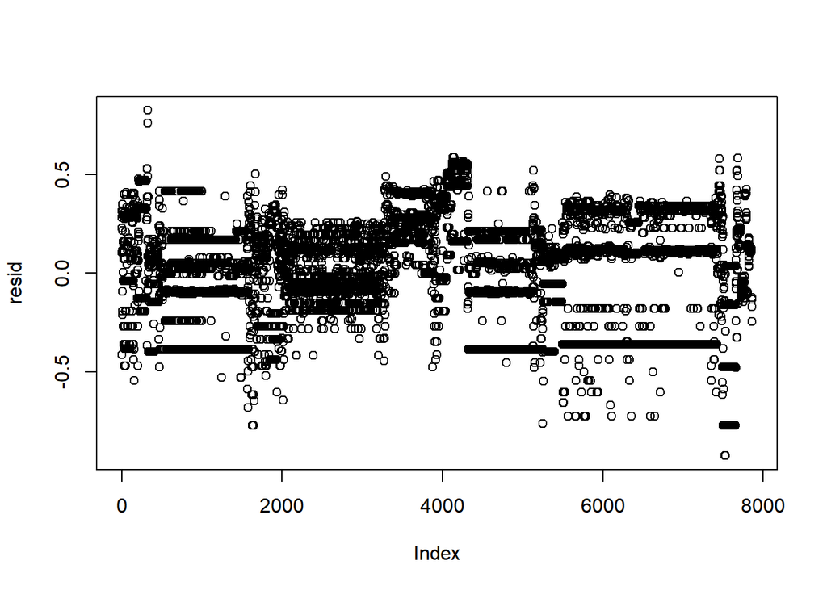

```r
alpha_s <- pm_params[1:4]
beta_s <- pm_params[5:8]
mean_s <- pm_params[1:4]/pm_params[5:8]
yhat = mean_s[data_jags$group_values]
resid = data_jags$RSCU - yhat
plot(resid)
```

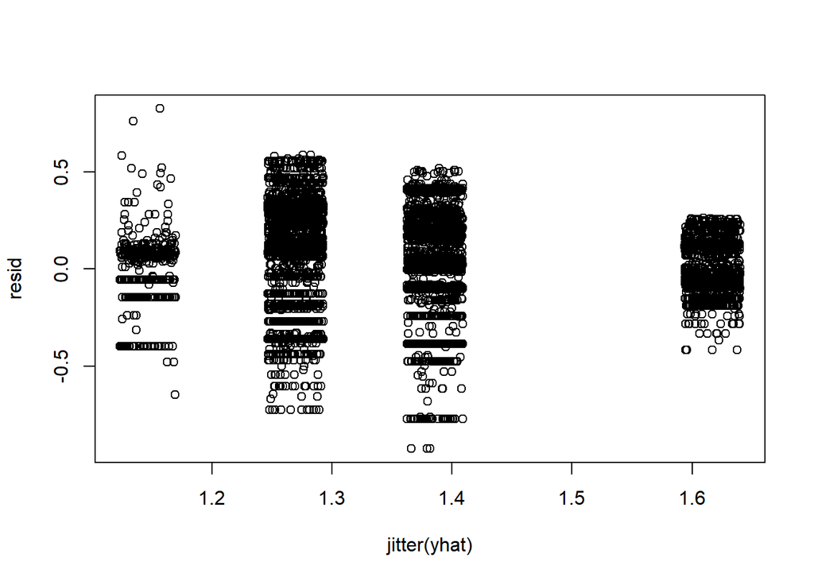

```r
plot(jitter(yhat), resid)
```

## Use the model

#### we can check the posterior probability that the RSCU values for the

Alphacoronavirus is greater than the RSCU values for the Betacoronavirus

```r
n_sim <- nrow(mod_csim)
set.seed(2019)
alpha_rscu_pred <- rgamma(n_sim,mod_csim[,1], mod_csim[,5])
beta_rscu_pred <- rgamma(n_sim,mod_csim[,2], mod_csim[,6])

mean(alpha_rscu_pred > beta_rscu_pred)
```

```
## [1] 0.3844247
```

The posterior probability is 0.384.